# Regression Models Course Project: Analysis of Mileage and Transmission Type

juradom

April 17, 2015

#### Executive Summary

The goal of this analysis is to answer the following two questions leveraging the mtcars dataset within R:

- Is an automatic or manual transmission better for MPG
- Quantify the MPG difference between automatic and manual transmissions"

#### Exploratory Analysis

As described in the R documentation, the mtcars dataset is derived from a 1974 Motor Trend magazine.

- **mtcars Structure**:
  - This data contains 32 observation of 11 variables.
  - 19 of the observations are automatic transmission; 13 are manual
  - *Appendix A* contains other structural info about the mtcars dataset.
- Research note: Around the time of the Motor Trend study, a 1975 EPA document was published indicating that weight and engine displacement are the most important factors in fuel economy (http://nepis.epa.gov/Exe/ZyPURL.cgi?Dockey=9100S2LD.txt)
- **Mean Values**: The average miles per gallon of the manual sample as: **24.39** and the automatic transmission mean as: **17.15**.
- **Variances**: The variances for manual and automatic transmission are: **38.03** and **14.7**, respectively. I suspect the variance issue is due to the small sample size so I will assume they are the same.
- **Normality**: *Appendix B* shows two density plots that appear to be normal but to be sure I performed a Shapiro test for normality. The p-value for the manual plot is: **0.54**. The p-value for the automatic plot is: **0.9**. Since null hypothesis in the Shapiro tests **against** the assumption of normalty, we cannot reject the null hypothesis because both p-values are > .05.

#### Regression Analysis

##### *Means Testing*

```r
example.model <- lm(mpg~am, data=mtcars)
am.t.test <- t.test(mtcars$mpg~mtcars$am)
```

The p-value for the t-test is: **0.0014**, therefore, we can reject the null hypothesis and determine that the two population means are different.

##### *Interpreting Coefficients And Finding The Best Fitting Model*

*Appendix C* summarizes the example model **lm(mpg~am)**. This model shows that manual transmissions yield about 7.2 mpg more than automatic, however it only explains 34% of the variance in mpg. This suggests there may be other factors that explain mpg. To do this we perform a Stepwise Algorithm. *Appendix D* shows the output for the best model and reveals that with this model ~83% of the variance in mpg can be explained–much better than the example model. The p-values are all < 0.05 which means that wt, qsec, and am are all significant variables.

```r
fit <- lm(mpg~., data=mtcars)
model.step <- step(fit)
best.step.model <- summary(model.step)$call
```

We conclude that the best formula via the Stepwise process is:

```
## lm(formula = mpg ~ wt + qsec + am, data = mtcars)
```

##### *Finding Interactions*

Below is a test to see if any interactions are significant to be added to our fitted model so far.

```r
am.wt <- summary(lm(formula = mpg ~ wt + qsec + am + am:wt, data = mtcars))$coef[5,4]
am.qsec <- summary(lm(formula = mpg ~ wt + qsec + am + am:qsec, data = mtcars))$coef[5,4]
qsec.wt <- summary(lm(formula = mpg ~ wt + qsec + am + qsec:wt, data = mtcars))$coef[5,4]
best.fit.model <- lm(formula = mpg ~ wt + qsec + am + am:wt, data = mtcars)
```

Based on the different combinations (*Appendix E*, it appears that the am:wt interaction with a p-value of: 0.0018. So our best fitted model is: **lm(formula = mpg ~ wt + qsec + am + am:wt, data = mtcars)** (*See Appendix F*)

##### *ANOVA*

```r
anova(example.model,best.fit.model)
```

```
## Analysis of Variance Table
##
## Model 1: mpg ~ am
## Model 2: mpg ~ wt + qsec + am + am:wt
##   Res.Df    RSS Df Sum of Sq      F    Pr(>F)
## 1     30 720.90
## 2     27 117.28  3    603.62 46.323 8.847e-11 ***
## ---
## Signif. codes:  0 '***' 0.001 '**' 0.01 '*' 0.05 '.' 0.1 ' ' 1
```

Based on our ANOVA analysis, we can can conclude that the best fitted model is significantly different from our example model, therefore we can reject the null hypothesis.

```r
auto.e <- round(summary(lm(formula = mpg ~ wt + qsec + am + am:wt, data = mtcars))$coef[1,1], digits=2)

manual.e <- round(summary(lm(formula = mpg ~ wt + qsec + am + am:wt, data = mtcars))$coef[4,1], digits=2)

net.e <- manual.e-auto.e
```

#### Appendix A: Structural Analysis of mtcars

```r
str(mtcars)
```

```
## 'data.frame':    32 obs. of  11 variables:
##  $ mpg : num  21 21 22.8 21.4 18.7 18.1 14.3 24.4 22.8 19.2 ...
##  $ cyl : num  6 6 4 6 8 6 8 4 4 6 ...
##  $ disp: num  160 160 108 258 360 ...
##  $ hp  : num  110 110 93 110 175 105 245 62 95 123 ...
##  $ drat: num  3.9 3.9 3.85 3.08 3.15 2.76 3.21 3.69 3.92 3.92 ...
##  $ wt  : num  2.62 2.88 2.32 3.21 3.44 ...
##  $ qsec: num  16.5 17 18.6 19.4 17 ...
##  $ vs  : Factor w/ 2 levels "V","S": 1 1 2 2 1 2 1 2 2 2 ...
##  $ am  : Factor w/ 2 levels "automatic","manual": 2 2 2 1 1 1 1 1 1 1 ...
##  $ gear: num  4 4 4 3 3 3 3 4 4 4 ...
##  $ carb: num  4 4 1 1 2 1 4 2 2 4 ...
```

#### Appendix B: Testing Normality

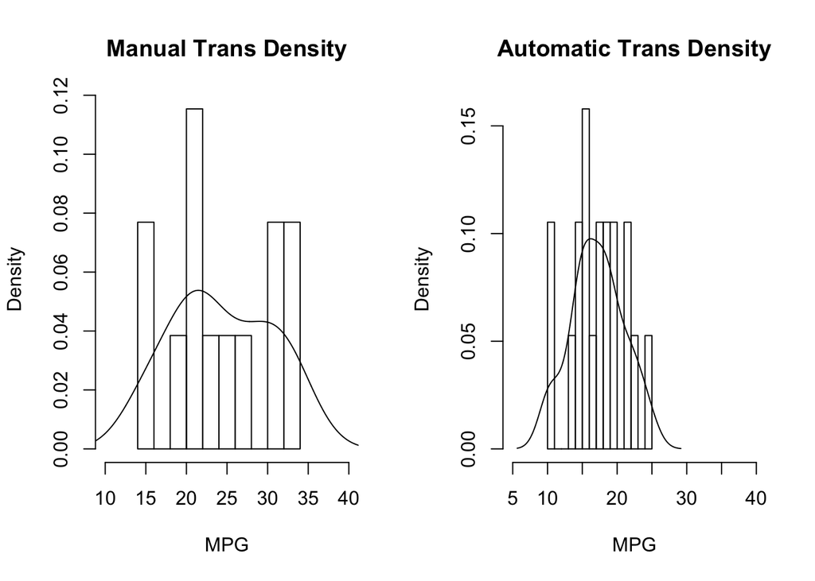

#### Appendix C: Summary Of The Base Model

```r
fit.example <- lm(formula = mpg ~ am, data = mtcars)
summary(fit.example)
```

```
##
## Call:
## lm(formula = mpg ~ am, data = mtcars)
##
## Residuals:
##     Min      1Q  Median      3Q     Max
## -9.3923 -3.0923 -0.2974  3.2439  9.5077
##
## Coefficients:
##             Estimate Std. Error t value Pr(>|t|)
## (Intercept)   17.147      1.125  15.247 1.13e-15 ***
## ammanual       7.245      1.764   4.106 0.000285 ***
## ---
## Signif. codes:  0 '***' 0.001 '**' 0.01 '*' 0.05 '.' 0.1 ' ' 1
##
## Residual standard error: 4.902 on 30 degrees of freedom
## Multiple R-squared:  0.3598, Adjusted R-squared:  0.3385
## F-statistic: 16.86 on 1 and 30 DF,  p-value: 0.000285
```

#### Appendix D: Summary Of The Best Step Model

```r
summary(model.step)
```

```
##
## Call:
## lm(formula = mpg ~ wt + qsec + am, data = mtcars)
##
## Residuals:
##     Min      1Q  Median      3Q     Max
## -3.4811 -1.5555 -0.7257  1.4110  4.6610
##
## Coefficients:
##             Estimate Std. Error t value Pr(>|t|)
## (Intercept)   9.6178     6.9596   1.382 0.177915
## wt           -3.9165     0.7112  -5.507 6.95e-06 ***
## qsec          1.2259     0.2887   4.247 0.000216 ***
## ammanual      2.9358     1.4109   2.081 0.046716 *
## ---
## Signif. codes:  0 '***' 0.001 '**' 0.01 '*' 0.05 '.' 0.1 ' ' 1
##
## Residual standard error: 2.459 on 28 degrees of freedom
## Multiple R-squared:  0.8497, Adjusted R-squared:  0.8336
## F-statistic: 52.75 on 3 and 28 DF,  p-value: 1.21e-11
```

#### Appendix E: Interactions

```r
am.wt <- summary(lm(formula = mpg ~ wt + qsec + am + am:wt, data = mtcars))$coef[5,4]
am.qsec <- summary(lm(formula = mpg ~ wt + qsec + am + am:qsec, data = mtcars))$coef[5,4]
qsec.wt <- summary(lm(formula = mpg ~ wt + qsec + am + qsec:wt, data = mtcars))$coef[5,4]
best.fit.model <- lm(formula = mpg ~ wt + qsec + am + am:wt, data = mtcars)
interaction <- c("am.wt","am.qsec","qsec.wt")
inter.coef <- c(am.wt, am.qsec,qsec.wt)
data.frame(interaction, inter.coef)
```

```
##   interaction  inter.coef
## 1       am.wt 0.001808576
## 2     am.qsec 0.038407879
## 3     qsec.wt 0.282397339
```

#### Appendix F: Summary of The Best Fit Model

```r
summary(best.fit.model)
```

```
##
## Call:
## lm(formula = mpg ~ wt + qsec + am + am:wt, data = mtcars)
##
## Residuals:
##     Min      1Q  Median      3Q     Max
## -3.5076 -1.3801 -0.5588  1.0630  4.3684
##
## Coefficients:
##             Estimate Std. Error t value Pr(>|t|)
## (Intercept)    9.723      5.899   1.648 0.110893
## wt            -2.937      0.666  -4.409 0.000149 ***
## qsec           1.017      0.252   4.035 0.000403 ***
## ammanual      14.079      3.435   4.099 0.000341 ***
## wt:ammanual   -4.141      1.197  -3.460 0.001809 **
## ---
## Signif. codes:  0 '***' 0.001 '**' 0.01 '*' 0.05 '.' 0.1 ' ' 1
##
## Residual standard error: 2.084 on 27 degrees of freedom
## Multiple R-squared:  0.8959, Adjusted R-squared:  0.8804
## F-statistic: 58.06 on 4 and 27 DF,  p-value: 7.168e-13
```

#### Appendix G: Residual Models

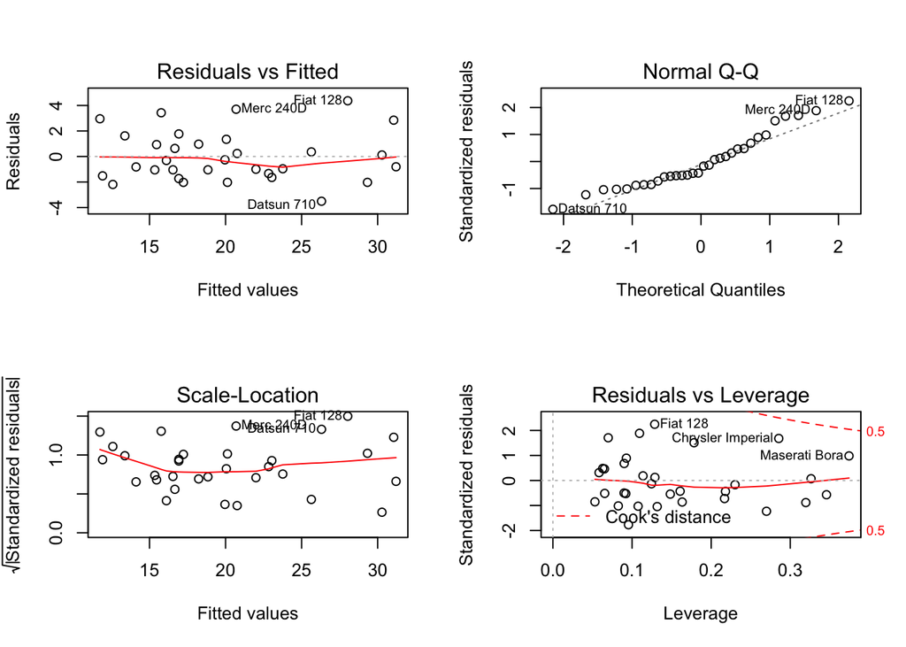

```r
par(mfrow = c(2,2))
plot(best.fit.model)
```